# Anemia

## **Enquadramento**

Este trabalho, desenvolvido no âmbito da unidade curricular “Métodos Estatísticos para a Bioinformática”, terá como referência o conjunto de dados “Anemia Diagnosis Dataset”, extraído da base de dados kaggle.

Segundo a Organização Mundial da Saúde, a anemia é uma condição caraterizada pela diminuição do número de glóbulos vermelhos ou da concentração de hemoglobina no sangue (World Health Organization,2022). O hemograma é um exame que, por meio de colheita de amostra sanguínea, avalia o número e a morfologia de células do sangue, sendo um exame laboratorial fundamental para o diagnóstico da anemia.

O conjunto de dados disponibilizado (dataset_anemia.xlsx) é utilizado para diagnosticar a prevalência de diferentes tipos de anemia, incluindo a sua severidade, com base em parâmetros de entrada como o sexo, a idade e vários valores resultantes de um hemograma realizado a 364 pacientes. Deste estudo foram excluídos lactentes, crianças com menos de 10 anos e grávidas.

De acordo com a teoria, níveis de RBC e/ou PCV menores levarão a níveis de HGB menores. Também um RDW alto no hemograma pode indicar anemia. Através dos conteúdos abordados nas aulas, iremos abordar a relação entre as variáveis em estudo, tentando construir um modelo de regressão linear que se ajuste aos nossos dados e que nos permita tirar informações no que diz respeito aos valores de um hemograma que podem estar alterados quando estamos perante valores de hemoglobina indicativos de anemia.

Assim, a nossa variável dependente será o nível de hemoglobina no sangue (HGB), e as variáveis independentes selecionadas serão: a idade (Age), o sexo (Sex), os níveis de glóbulos vermelhos no sangue (RBC), o volume de glóbulos vermelhos no sangue (PCV), o volume celular médio (MCV), a hemoglobina celular média (MCH), a distribuição do tamanho dos glóbulos vermelhos (RDW) e a contagem de glóbulos brancos (TLC).

## **Base de dados**

“Anemia Diagnosis Dataset” (disponível em https://encr.pw/Rxu0N). Dada a extensão do data frame, para ilustração, apenas estão a ser exibidas as primeiras dez linhas.

| Age | Sex | RBC | PCV | MCV | MCH | RDW | TLC | HGB |
| --- | --- | --- | --- | --- | --- | --- | --- | --- |
| 28 | 0 | 5.66 | 34 | 60.1 | 17 | 20 | 11.1 | 9.6 |
| 41 | 0 | 4.78 | 44.5 | 93.1 | 28.9 | 13 | 7.02 | 13.8 |
| 40 | 1 | 4.65 | 41.6 | 89.5 | 28.8 | 13 | 8.09 | 13.4 |
| 76 | 0 | 4.24 | 36.7 | 86.6 | 26.7 | 14.9 | 13.41 | 11.3 |
| 20 | 1 | 4.14 | 36.9 | 89.1 | 27.8 | 13.2 | 4.75 | 11.5 |
| 24 | 0 | 4.29 | 40.1 | 93.5 | 29.6 | 14.5 | 13.96 | 12.7 |
| 28 | 1 | 4.98 | 42.3 | 84.9 | 24.9 | 16.2 | 9.33 | 12.4 |
| 14 | 0 | 4.97 | 43.8 | 88.1 | 28 | 15.2 | 3.92 | 13.9 |
| 16 | 0 | 4.16 | 38.7 | 93 | 28.8 | 17.9 | 5.77 | 12 |
| 62 | 0 | 5.25 | 45.6 | 86.9 | 25.3 | 15.6 | 10.68 | 13.3 |

## **Dicionário de dados**

- **HGB (Hemoglobin)**: Níveis de hemoglobina (g/dL).
- **Age**: idade do paciente.
- **Sex**: sexo (0-masculino, 1-feminino).
- **RBC** (Red blood cell count): níveis de glóbulos vermelhos (g/dL).
- **PCV (Packed cell volume)**: volume de glóbulos vermelhos no sangue (%).
- **MCV (Mean Cell Volume)**: volume celular médio (fL/glóbulo vermelho).
- **MCH (Mean Cell Hemoglobin)**: Hemoglobina celular media (pg).
- **RDW (Red cell distribution width)**: Distribuição do tamanho dos glóbulos vermelhos (%).
- **TLC (Total Leucocyte Count- White Blood Cell count)**: Contagem de Glóbulos Brancos (ths/uL).

## **Análise Exploratória das variáveis quantitativas, histogramas e boxplot**

As variáveis selecionadas da nossa base de dados podem ser classificadas em quantitativas proporcionais contínuas (HGB, Age, RBC, PCV, MCV, MCH, RDW) e em quantitativas proporcionais discretas (TLC).

### Mínimo, 1ºquartil, mediana, média, 3ºquartil, máximo

```
##       Age             Sex              RBC             PCV
##  Min.   :11.00   Min.   :0.0000   Min.   :1.360   Min.   :13.10
##  1st Qu.:28.00   1st Qu.:0.0000   1st Qu.:3.780   1st Qu.:32.90
##  Median :44.50   Median :0.0000   Median :4.335   Median :36.80
##  Mean   :44.92   Mean   :0.4423   Mean   :4.279   Mean   :36.76
##  3rd Qu.:60.00   3rd Qu.:1.0000   3rd Qu.:4.800   3rd Qu.:41.85
##  Max.   :89.00   Max.   :1.0000   Max.   :6.900   Max.   :56.90
##       MCV              MCH             RDW             TLC
##  Min.   : 55.70   Min.   :14.70   Min.   :10.60   Min.   : 2.000
##  1st Qu.: 83.17   1st Qu.:26.30   1st Qu.:13.60   1st Qu.: 5.900
##  Median : 87.95   Median :28.20   Median :14.80   Median : 7.935
##  Mean   : 87.51   Mean   :28.23   Mean   :15.12   Mean   : 8.864
##  3rd Qu.: 91.88   3rd Qu.:30.40   3rd Qu.:16.10   3rd Qu.:10.205
##  Max.   :124.10   Max.   :41.40   Max.   :29.20   Max.   :42.420
##       HGB
##  Min.   : 4.20
##  1st Qu.:10.60
##  Median :12.10
##  Mean   :11.91
##  3rd Qu.:13.40
##  Max.   :19.60
```

### Desvios-padrão

| id | Nome | Sd |
| --- | --- | --- |
| 1 | Age | 18.78 |
| 2 | RBC | 0.82 |
| 3 | PCV | 6.83 |
| 4 | MCV | 9.33 |
| 5 | MCH | 3.87 |
| 6 | RDW | 2.18 |
| 7 | TLC | 4.87 |
| 8 | HGB | 2.19 |

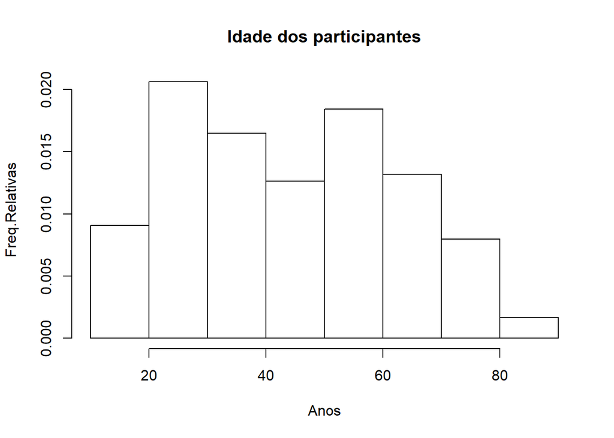

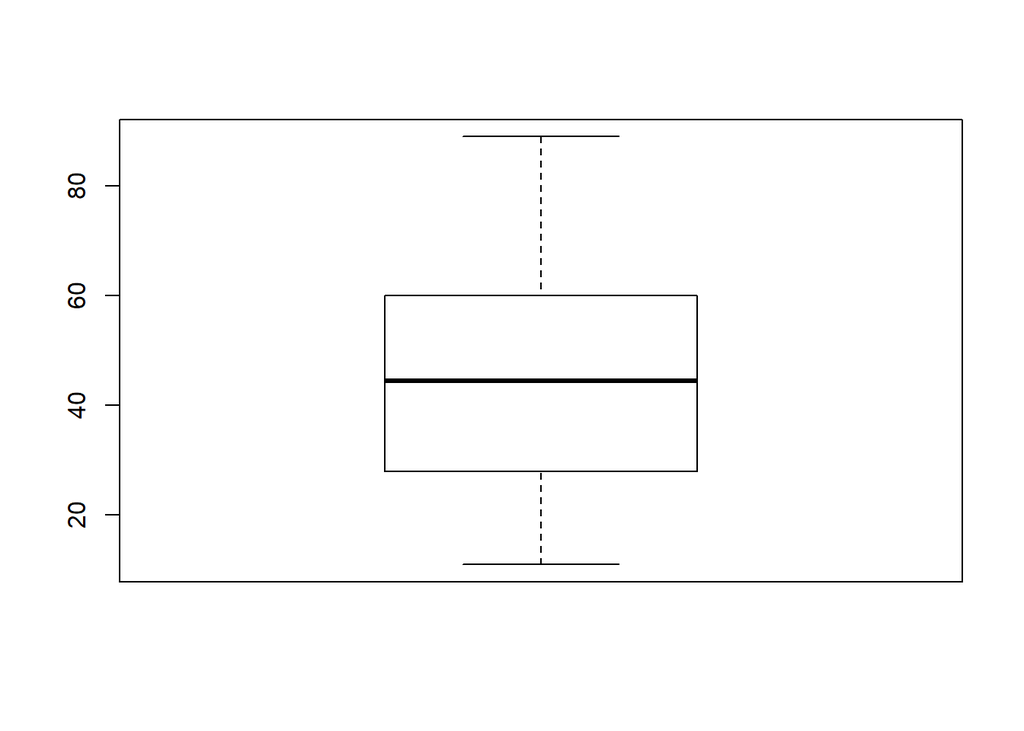

Relativamente à variável “Idade” verificamos que não existem outliers, a idade mínima registada foram 11 anos e a idade máxima 89 anos.

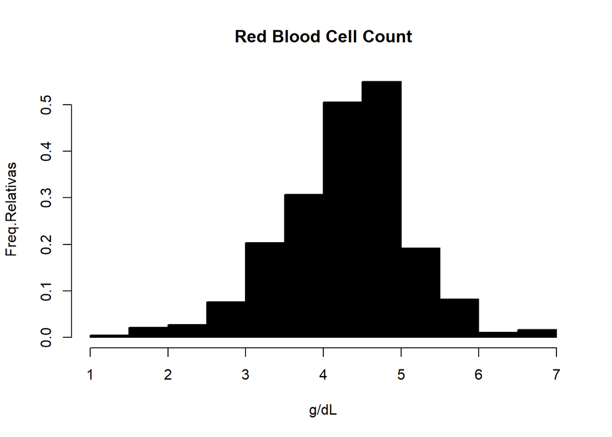

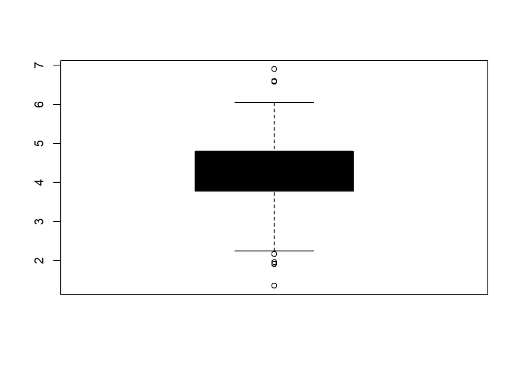

Relativamente à variável “Red Blood Cell Count” destacamos a presença de outliers.

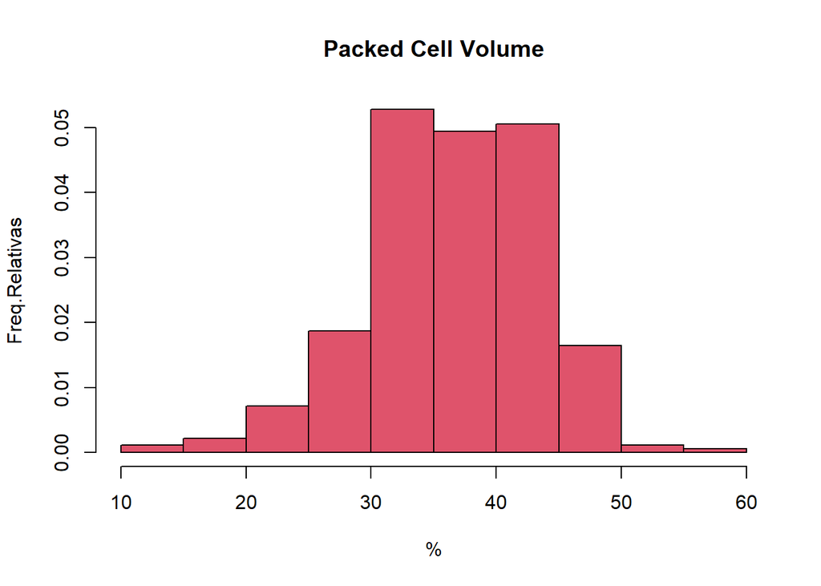

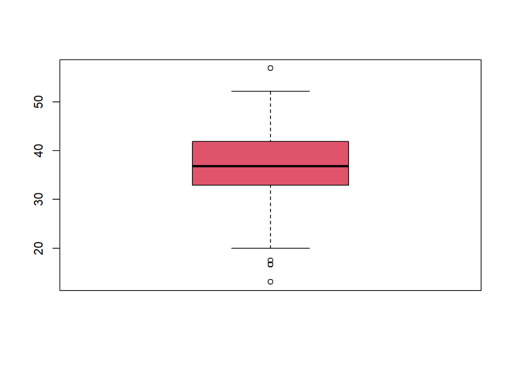

Relativamente à variàvel “Packed Cell Volume” registamos a presença de outliers.

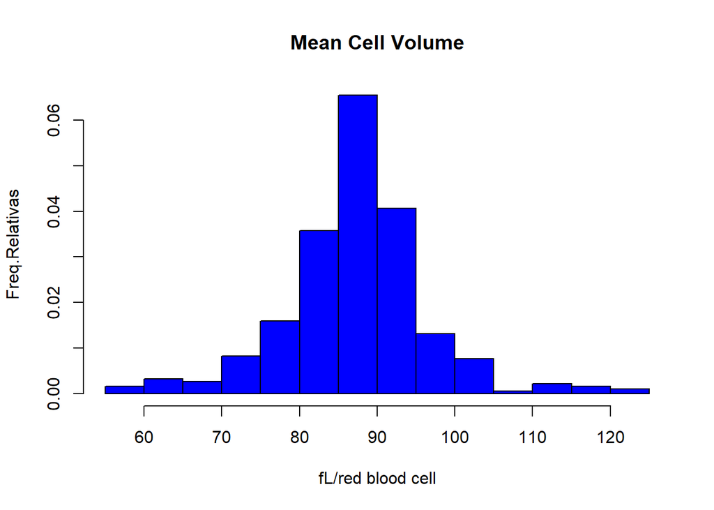

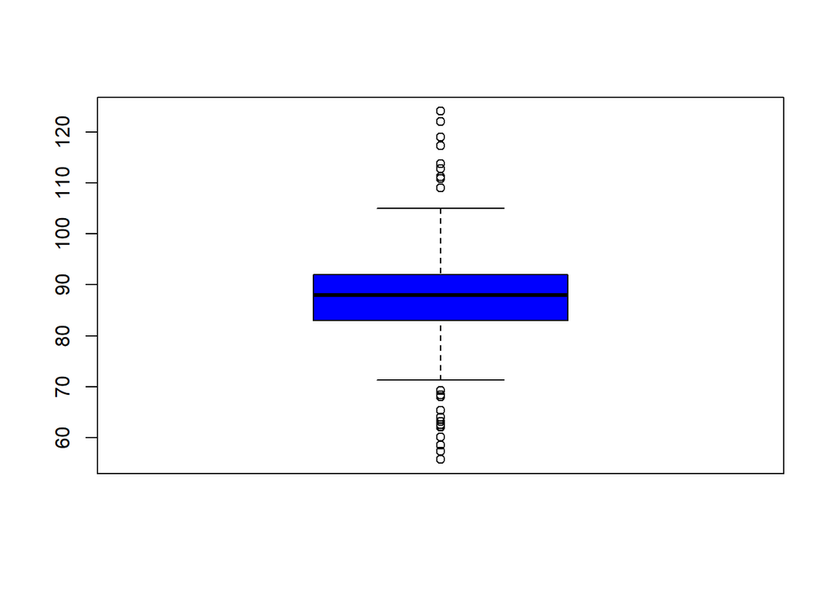

Relativamente à variàvel “Mean Cell Volume” registamos a presença de muitos outliers.

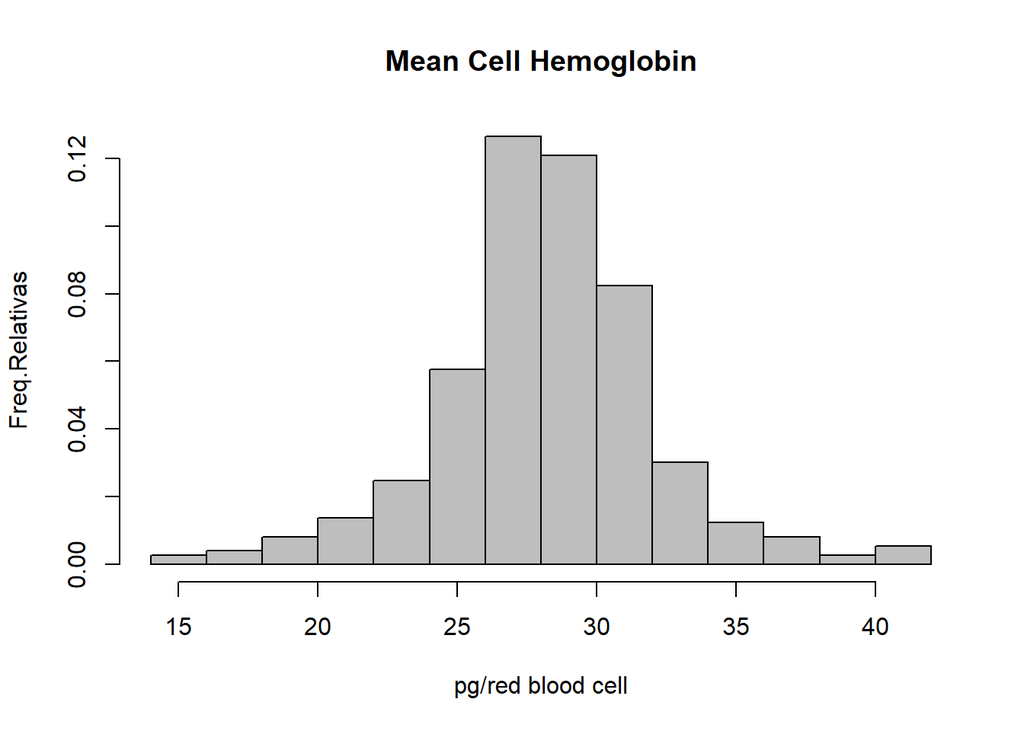

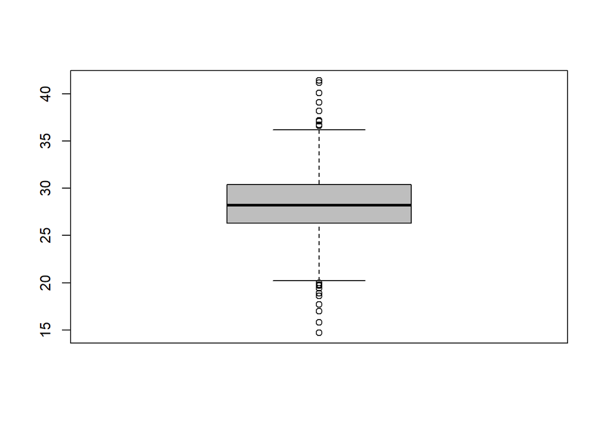

Relativamente à variàvel “Mean Cell Hemoglobin” registamos a presença de muitos outliers.

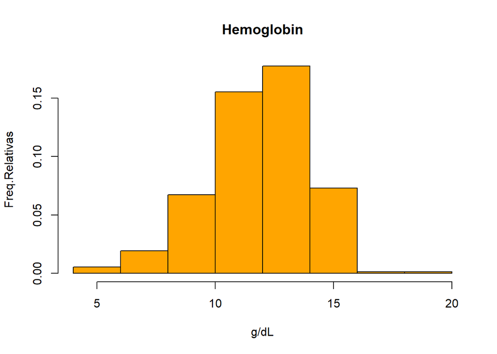

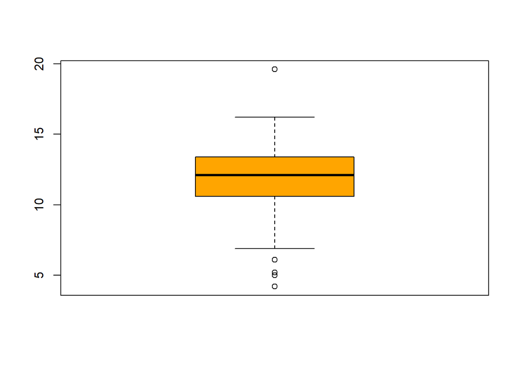

Relativamente à variàvel dependente “Hemoglobin” registamos a presença de alguns outliers.

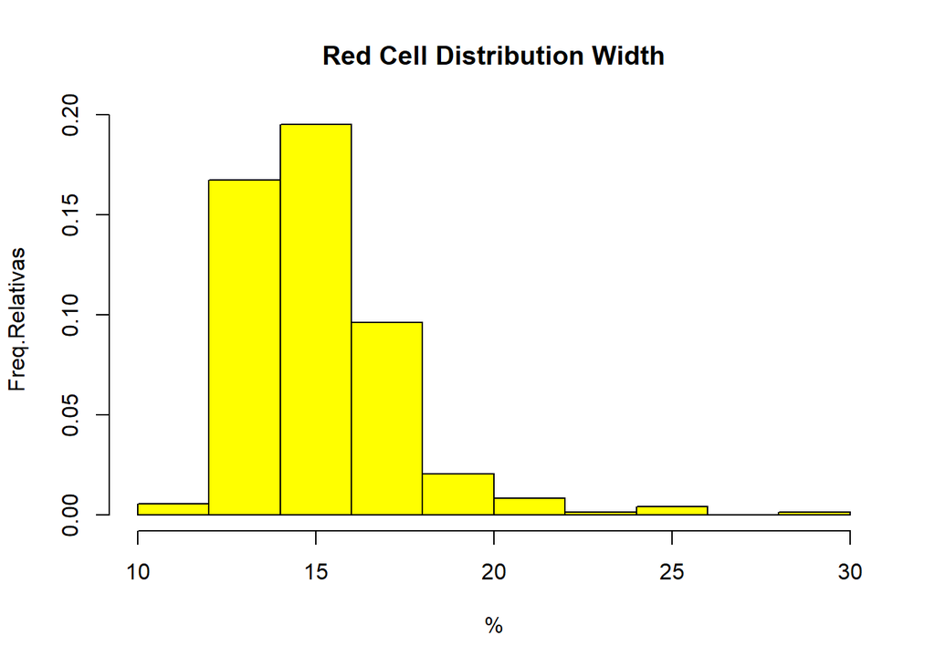

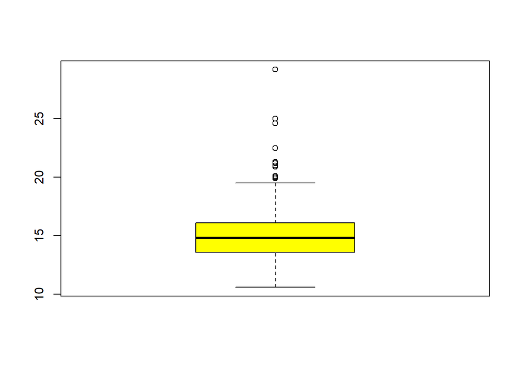

Relativamente à variável “Red Cell Distribution Width” verificamos que há uma assimetria à direita na distribuição dos valores, havendo também presença de outliers.

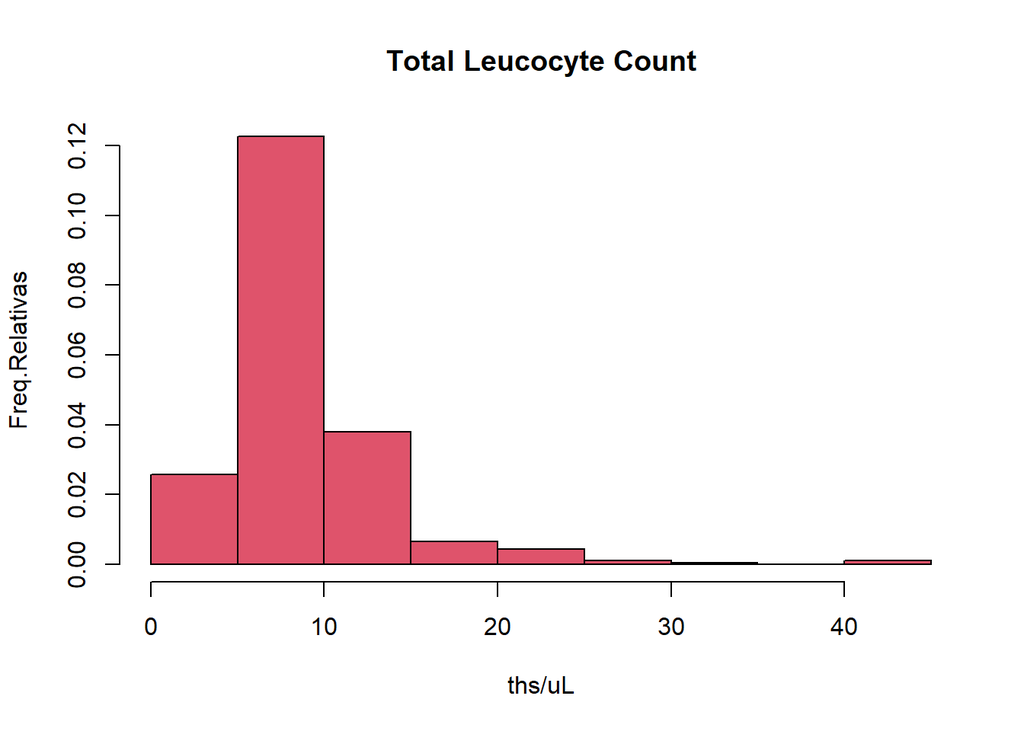

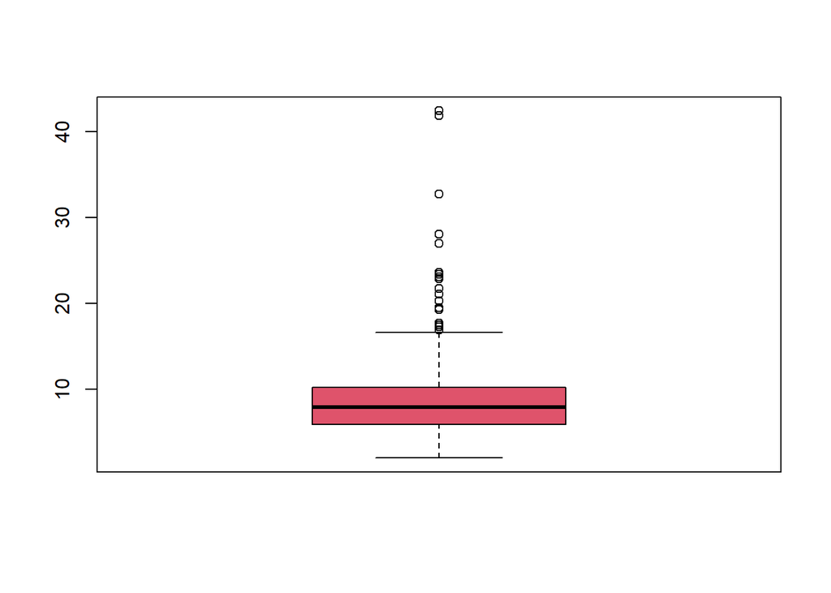

Relativamente à variável “Total Leucocyte Count” verificamos que há uma assimetria à direita na distribuição dos valores, havendo também presença de outliers.

## **Análise Exploratória das variáveis qualitativas e gráfico de barras**

Sex- variável qualitativa nominal.

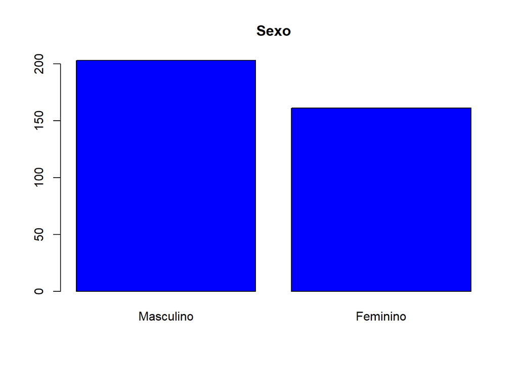

Do total de participantes, 203 eram do sexo masculino e 161 do sexo feminino.

## **Matriz de correlação entre as variáveis quantitativas**

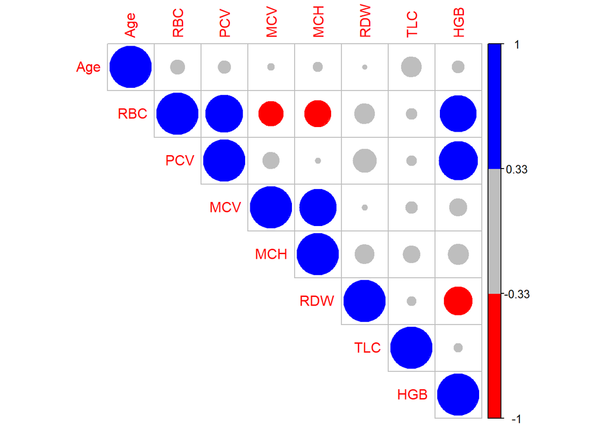

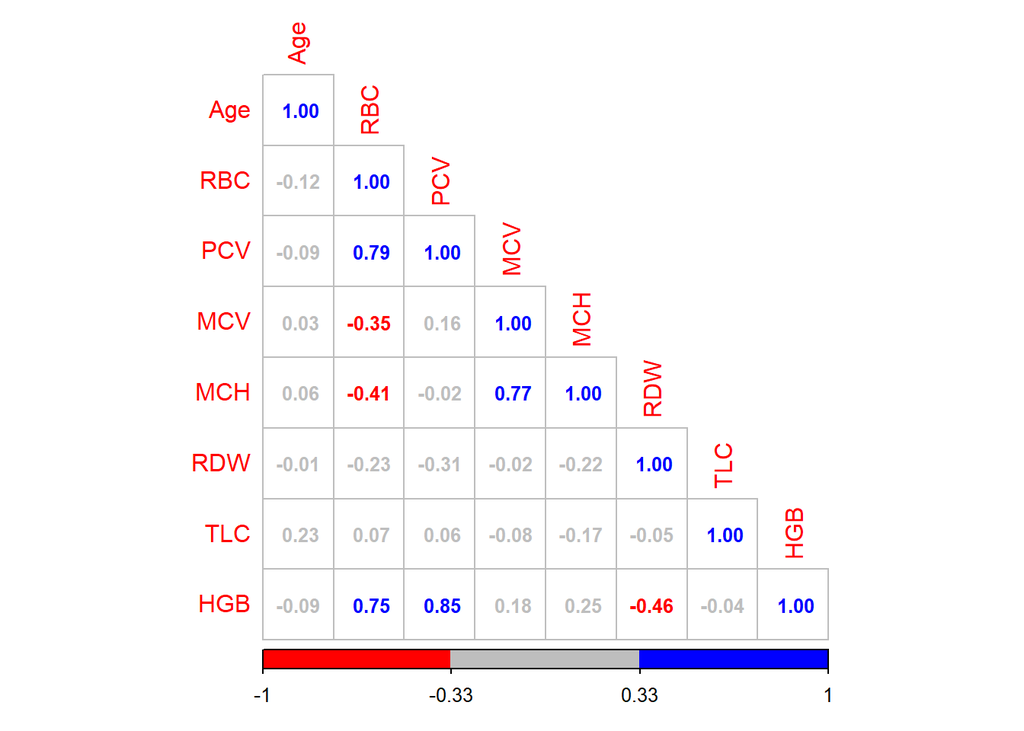

Através do gráfico de correlação, podemos concluir que existem correlações relevantes entre as variáveis em estudo, positivamente: PCV com RBC; MCH com MCV; HGB com RBC ; HGB com PCV e negativamente: RBC com MCV ; RBC com MCH ; RDW com HGB.

## **Construção de um modelo de regressão linear múltiplo**

**Nota:**para todos os testes estatísticos abaixo realizados, considere-se um valor de prova igual a 0.05.

### Modelo com a todas as variáveis disponíveis

```
##
## Call:
## lm(formula = dataset_anemia$HGB ~ ., data = dataset_anemia)
##
## Residuals:
##     Min      1Q  Median      3Q     Max
## -2.4597 -0.1679 -0.0001  0.2164  3.1706
##
## Coefficients:
##               Estimate Std. Error t value Pr(>|t|)
## (Intercept) -5.9741698  0.5656745 -10.561  < 2e-16 ***
## Age         -0.0003159  0.0014890  -0.212  0.83212
## Sex          0.0015037  0.0594695   0.025  0.97984
## RBC          1.8776715  0.0873326  21.500  < 2e-16 ***
## PCV          0.0944516  0.0100883   9.362  < 2e-16 ***
## MCV         -0.0178405  0.0061873  -2.883  0.00417 **
## MCH          0.3280381  0.0130051  25.224  < 2e-16 ***
## RDW         -0.0807167  0.0143177  -5.638 3.52e-08 ***
## TLC         -0.0100644  0.0057891  -1.739  0.08299 .
## ---
## Signif. codes:  0 '***' 0.001 '**' 0.01 '*' 0.05 '.' 0.1 ' ' 1
##
## Residual standard error: 0.5072 on 355 degrees of freedom
## Multiple R-squared:  0.9474, Adjusted R-squared:  0.9462
## F-statistic: 799.1 on 8 and 355 DF,  p-value: < 2.2e-16
```

```
H0: o modelo não é estatísticamente significativo.
H1: o modelo é estatísticamente significativo.
```

Podemos verificar uma estatística de teste F(8,355)=799.1 e um valor de prova < 2.2e-16, logo rejeitamos H0 e o modelo é estatísticamente significativo, ou seja, pelo menos uma variável preditiva está relacionada com a variável resposta. Olhando para a tabela dos coeficientes, podemos dizer que apenas as variáveis “Age”, “Sex” e “TLC” não são significativas para o modelo. Por último, verificamos também um valor de $R^2$ ajustado de 0.9462, o que representa um ótimo valor, significando que cerca de 95% da variabilidade dependente pode ser explicada por este modelo.

### Modelo de regressão utilizando as técnicas de stepwise

#### **Both**

```
## Start:  AIC=-485.36
## dataset_anemia$HGB ~ Age + Sex + RBC + PCV + MCV + MCH + RDW +
##     TLC
##
##        Df Sum of Sq     RSS     AIC
## - Sex   1     0.000  91.313 -487.36
## - Age   1     0.012  91.325 -487.31
## <none>               91.313 -485.36
## - TLC   1     0.777  92.091 -484.27
## - MCV   1     2.139  93.452 -478.93
## - RDW   1     8.175  99.488 -456.15
## - PCV   1    22.547 113.860 -407.04
## - RBC   1   118.903 210.216 -183.84
## - MCH   1   163.653 254.967 -113.59
##
## Step:  AIC=-487.36
## dataset_anemia$HGB ~ Age + RBC + PCV + MCV + MCH + RDW + TLC
##
##        Df Sum of Sq     RSS     AIC
## - Age   1     0.012  91.326 -489.31
## <none>               91.313 -487.36
## - TLC   1     0.777  92.091 -486.27
## + Sex   1     0.000  91.313 -485.36
## - MCV   1     2.140  93.453 -480.93
## - RDW   1     8.201  99.515 -458.05
## - PCV   1    22.549 113.862 -409.03
## - RBC   1   121.957 213.271 -180.59
## - MCH   1   175.224 266.538  -99.44
##
## Step:  AIC=-489.31
## dataset_anemia$HGB ~ RBC + PCV + MCV + MCH + RDW + TLC
##
##        Df Sum of Sq     RSS     AIC
## <none>               91.326 -489.31
## - TLC   1     0.880  92.205 -487.82
## + Age   1     0.012  91.313 -487.36
## + Sex   1     0.001  91.325 -487.31
## - MCV   1     2.130  93.456 -482.92
## - RDW   1     8.197  99.522 -460.03
## - PCV   1    22.542 113.868 -411.01
## - RBC   1   122.477 213.802 -181.69
## - MCH   1   175.626 266.952 -100.87
```

```
##
## Call:
## lm(formula = dataset_anemia$HGB ~ RBC + PCV + MCV + MCH + RDW +
##     TLC, data = dataset_anemia)
##
## Residuals:
##     Min      1Q  Median      3Q     Max
## -2.4525 -0.1700 -0.0003  0.2209  3.1777
##
## Coefficients:
##              Estimate Std. Error t value Pr(>|t|)
## (Intercept) -5.985524   0.527146 -11.355  < 2e-16 ***
## RBC          1.878368   0.085845  21.881  < 2e-16 ***
## PCV          0.094432   0.010060   9.387  < 2e-16 ***
## MCV         -0.017784   0.006163  -2.886  0.00414 **
## MCH          0.327798   0.012510  26.202  < 2e-16 ***
## RDW         -0.080709   0.014258  -5.660  3.1e-08 ***
## TLC         -0.010374   0.005594  -1.855  0.06448 .
## ---
## Signif. codes:  0 '***' 0.001 '**' 0.01 '*' 0.05 '.' 0.1 ' ' 1
##
## Residual standard error: 0.5058 on 357 degrees of freedom
## Multiple R-squared:  0.9474, Adjusted R-squared:  0.9465
## F-statistic:  1071 on 6 and 357 DF,  p-value: < 2.2e-16
```

```
H0: o modelo_b não é estatísticamente significativo.
H1: o modelo_b é estatísticamente significativo.
```

Podemos verificar uma estatística de teste F(6,357)=1071 e um valor de prova < 2.2e-16, logo rejeitamos H0 e o modelo_b é estatísticamente significativo, ou seja, pelo menos uma variável preditiva está relacionada com a variável resposta. Olhando para a tabela dos coeficientes, verificamos que foram removidas as variáveis “Age” e “Sex”, mantendo-se a variável “TLC” que não é significativas para o modelo. Por último, verificamos também um valor de $R^2$ ajustado de 0.9465, o que representa um ótimo valor, significando que cerca de 95% da variabilidade dependente pode ser explicada por este modelo_b.

#### **Backward**

```
## Start:  AIC=-485.36
## dataset_anemia$HGB ~ Age + Sex + RBC + PCV + MCV + MCH + RDW +
##     TLC
##
##        Df Sum of Sq     RSS     AIC
## - Sex   1     0.000  91.313 -487.36
## - Age   1     0.012  91.325 -487.31
## <none>               91.313 -485.36
## - TLC   1     0.777  92.091 -484.27
## - MCV   1     2.139  93.452 -478.93
## - RDW   1     8.175  99.488 -456.15
## - PCV   1    22.547 113.860 -407.04
## - RBC   1   118.903 210.216 -183.84
## - MCH   1   163.653 254.967 -113.59
##
## Step:  AIC=-487.36
## dataset_anemia$HGB ~ Age + RBC + PCV + MCV + MCH + RDW + TLC
##
##        Df Sum of Sq     RSS     AIC
## - Age   1     0.012  91.326 -489.31
## <none>               91.313 -487.36
## - TLC   1     0.777  92.091 -486.27
## - MCV   1     2.140  93.453 -480.93
## - RDW   1     8.201  99.515 -458.05
## - PCV   1    22.549 113.862 -409.03
## - RBC   1   121.957 213.271 -180.59
## - MCH   1   175.224 266.538  -99.44
##
## Step:  AIC=-489.31
## dataset_anemia$HGB ~ RBC + PCV + MCV + MCH + RDW + TLC
##
##        Df Sum of Sq     RSS     AIC
## <none>               91.326 -489.31
## - TLC   1     0.880  92.205 -487.82
## - MCV   1     2.130  93.456 -482.92
## - RDW   1     8.197  99.522 -460.03
## - PCV   1    22.542 113.868 -411.01
## - RBC   1   122.477 213.802 -181.69
## - MCH   1   175.626 266.952 -100.87
```

```
##
## Call:
## lm(formula = dataset_anemia$HGB ~ RBC + PCV + MCV + MCH + RDW +
##     TLC, data = dataset_anemia)
##
## Residuals:
##     Min      1Q  Median      3Q     Max
## -2.4525 -0.1700 -0.0003  0.2209  3.1777
##
## Coefficients:
##              Estimate Std. Error t value Pr(>|t|)
## (Intercept) -5.985524   0.527146 -11.355  < 2e-16 ***
## RBC          1.878368   0.085845  21.881  < 2e-16 ***
## PCV          0.094432   0.010060   9.387  < 2e-16 ***
## MCV         -0.017784   0.006163  -2.886  0.00414 **
## MCH          0.327798   0.012510  26.202  < 2e-16 ***
## RDW         -0.080709   0.014258  -5.660  3.1e-08 ***
## TLC         -0.010374   0.005594  -1.855  0.06448 .
## ---
## Signif. codes:  0 '***' 0.001 '**' 0.01 '*' 0.05 '.' 0.1 ' ' 1
##
## Residual standard error: 0.5058 on 357 degrees of freedom
## Multiple R-squared:  0.9474, Adjusted R-squared:  0.9465
## F-statistic:  1071 on 6 and 357 DF,  p-value: < 2.2e-16
```

```
H0: o modelo_back não é estatísticamente significativo.
H1: o modelo_back é estatísticamente significativo.
```

Podemos verificar uma estatística de teste F(6,357)=1071 e um valor de prova < 2.2e-16, logo rejeitamos H0 e o modelo_back é estatísticamente significativo, ou seja, pelo menos uma variável preditiva está relacionada com a variável resposta. Olhando para a tabela dos coeficientes, verificamos que foram removidas novamente as variáveis “Age” e “Sex”, mantendo-se a variável “TLC” que não é significativas para o modelo. Por último, verificamos também um valor de $R^2$ ajustado de 0.9465, o que representa um ótimo valor, significando que cerca de 95% da variabilidade dependente pode ser explicada por este modelo_b.

#### **Forward**

```
## Start:  AIC=-485.36
## dataset_anemia$HGB ~ Age + Sex + RBC + PCV + MCV + MCH + RDW +
##     TLC
```

```
##
## Call:
## lm(formula = dataset_anemia$HGB ~ Age + Sex + RBC + PCV + MCV +
##     MCH + RDW + TLC, data = dataset_anemia)
##
## Residuals:
##     Min      1Q  Median      3Q     Max
## -2.4597 -0.1679 -0.0001  0.2164  3.1706
##
## Coefficients:
##               Estimate Std. Error t value Pr(>|t|)
## (Intercept) -5.9741698  0.5656745 -10.561  < 2e-16 ***
## Age         -0.0003159  0.0014890  -0.212  0.83212
## Sex          0.0015037  0.0594695   0.025  0.97984
## RBC          1.8776715  0.0873326  21.500  < 2e-16 ***
## PCV          0.0944516  0.0100883   9.362  < 2e-16 ***
## MCV         -0.0178405  0.0061873  -2.883  0.00417 **
## MCH          0.3280381  0.0130051  25.224  < 2e-16 ***
## RDW         -0.0807167  0.0143177  -5.638 3.52e-08 ***
## TLC         -0.0100644  0.0057891  -1.739  0.08299 .
## ---
## Signif. codes:  0 '***' 0.001 '**' 0.01 '*' 0.05 '.' 0.1 ' ' 1
##
## Residual standard error: 0.5072 on 355 degrees of freedom
## Multiple R-squared:  0.9474, Adjusted R-squared:  0.9462
## F-statistic: 799.1 on 8 and 355 DF,  p-value: < 2.2e-16
```

```
H0: o modelo_for não é estatísticamente significativo.
H1: o modelo_for é estatísticamente significativo.
```

Podemos verificar uma estatística de teste F(8,355)=799.1 e um valor de prova < 2.2e-16, logo rejeitamos H0 e o modelo_for é estatísticamente significativo, ou seja, pelo menos uma variável preditiva está relacionada com a variável resposta. Olhando para a tabela dos coeficientes, verificamos que foram mantidas as variáveis “Age”, “Sex” e “TLC” que não são significativas para o modelo. Por último, verificamos também um valor de $R^2$ ajustado de 0.9462, o que representa um ótimo valor, significando que cerca de 95% da variabilidade dependente pode ser explicada por este modelo_b.

#### Avaliação dos vários modelos

```
## Analysis of Variance Table
##
## Model 1: dataset_anemia$HGB ~ Age + Sex + RBC + PCV + MCV + MCH + RDW +
##     TLC
## Model 2: dataset_anemia$HGB ~ RBC + PCV + MCV + MCH + RDW + TLC
## Model 3: dataset_anemia$HGB ~ RBC + PCV + MCV + MCH + RDW + TLC
## Model 4: dataset_anemia$HGB ~ Age + Sex + RBC + PCV + MCV + MCH + RDW +
##     TLC
##   Res.Df    RSS Df Sum of Sq     F Pr(>F)
## 1    355 91.313
## 2    357 91.326 -2 -0.012332 0.024 0.9763
## 3    357 91.326  0  0.000000
## 4    355 91.313  2  0.012332 0.024 0.9763
```

Ao compararmos os valores de RSS (Residual Sum of Squares), medida que quantifica a variação não explicada pelo modelo de regressão (diferenças entre os valores observados e os previstos pelo modelo), verificamos que o modelo_comp e o modelo_for possuem os menores valores de RSS, ou seja, serão os modelos melhor ajustados. No entanto, todos os valores estão muito próximos. Métricas como o AIC e o BIC fornecem uma visão mais completa da capacidade explicativa do modelo e consideram a complexidade do modelo.

```
##             df      AIC
## modelo_comp 10 549.6266
## modelo_b     8 545.6758
## modelo_back  8 545.6758
## modelo_for  10 549.6266
```

```
##             df      BIC
## modelo_comp 10 588.5982
## modelo_b     8 576.8530
## modelo_back  8 576.8530
## modelo_for  10 588.5982
```

Observamos que os modelos com valores mais baixos de AIC(Critério de Informação de Akaike) e de BIC(Critério de Informação Bayesiano) são o modelo_b e o modelo_back. Ou seja, serão modelos equilibrados em termos qualidade de ajuste e complexidade.

**Conclusão** Entre os modelos testados, o modelo_b e o modelo_back têm os menores valores de AIC/BIC e o mesmo valor de $R^2$, ou seja, ambos são modelos com um bom ajuste. Iremos prosseguir com o modelo_b (modelo derivado da técnica stepwise-both).

## **Avaliação do modelo adotado**

### Análise dos valores de prova dos coeficientes

```
H0:a regressão linear não é significativa entre HGB e a variável independente.
H0:a regressão linear é significativa entre HBG e a variável independente.
```

De acordo com o valor de prova definido (α=5%), apenas a relação entre HGB-TLC não é estatisticamente significativa (Pr(>|t|)=0.06448).

### Significância estatística do modelo

```
H0:o modelo não é estatisticamente significativo.
H1:o modelo é estatisticamente significativo.
```

De acordo com o valor de prova definido (α=5%), existe evidência estatística para rejeitar a hipótese nula e por isso o modelo é estatisticamente significativo (p-value< 2.2e-16).

### Análise do coeficiente de determinação

Através da analise do valor de $R^2$ (0.9465), verificamos que cerca de 95% da variabilidade dependente pode ser explicada por este modelo_b, ou seja, o modelo é bem ajustado.

## Análise dos gráficos dos resíduos

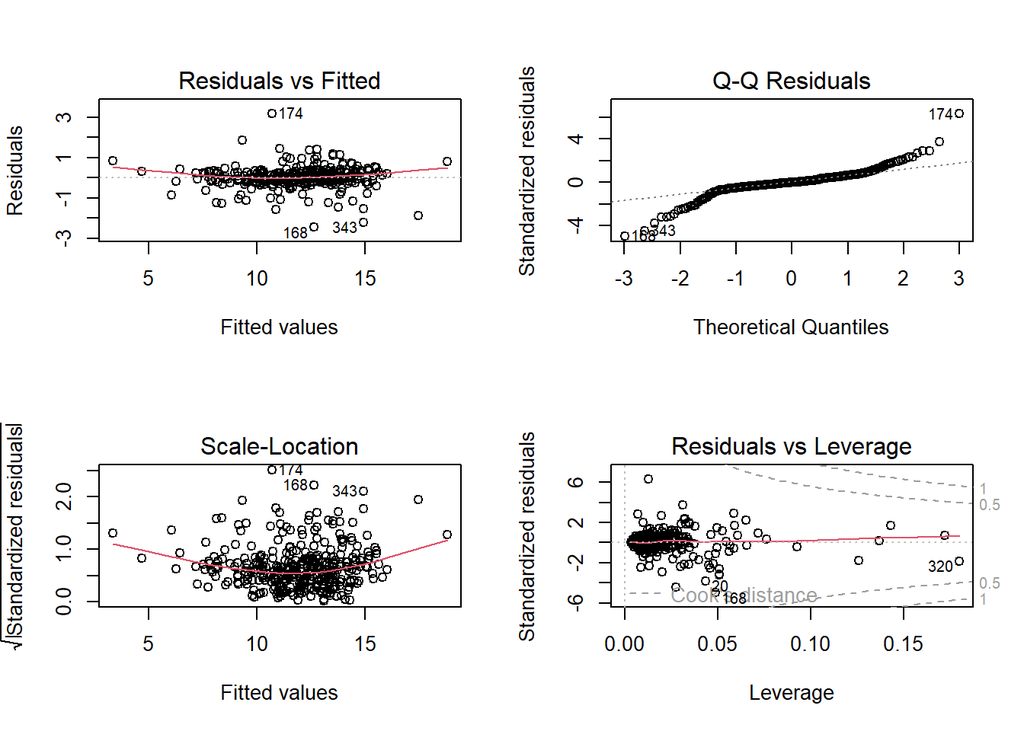

### Linearidade

No primeiro gráfico podemos observar que a linha vermelha aproxima-se da horizontalidade, havendo uma grande concentração da maioria dos dados em volta de zero, ou seja, aceitamos a existência de linearidade.

### Normalidade

```
H0:os resíduos são normais.
H1:os resíduos não são normais.
```

```r
  norm_res=shapiro.test(modelo_b$residuals)
  norm_res
```

```
##
##  Shapiro-Wilk normality test
##
## data:  modelo_b$residuals
## W = 0.85573, p-value < 2.2e-16
```

```
## Rejeito H0, os resíduos não são normais.
```

Através da análise do Q-Q Plot, verificamos que os pontos estão, na sua maioria, sobrepostos à linha diagonal. Apenas as extremidades se afastam abaixo e acima da diagonal. No entanto, sabemos que temos um grande volume de dados (n=364), e que, de acordo com o teorema do limite central, podemos aceitar a normalidade dos resíduos apesar de o valor de p-value do teste de shapiro nos levar a rejeitar a hipótese nula.

### Média

```
H0:os resíduos têm média zero.
H1:os resíduos não têm média zero.
```

```r
  media_res=t.test(modelo_b$residuals)
  media_res
```

```
##
##  One Sample t-test
##
## data:  modelo_b$residuals
## t = 1.7746e-16, df = 363, p-value = 1
## alternative hypothesis: true mean is not equal to 0
## 95 percent confidence interval:
##  -0.0517  0.0517
## sample estimates:
##    mean of x
## 4.665495e-18
```

```
## Não existe evidência estatística para rejeitar H0, os resíduos têm média zero.
```

### Homocedasticidade

```
H0:A variabilidade dos resíduos é constante em todas as faixas dos valores ajustados (homocedasticidade).
H1:A variabilidade dos resíduos não é constante em todas as faixas dos valores ajustados (heterocedasticidade).
```

```r
    bptest(modelo_b)
```

```
##
##  studentized Breusch-Pagan test
##
## data:  modelo_b
## BP = 30.484, df = 6, p-value = 3.18e-05
```

Através da análise do gráfico “Sacale-Location” podemos ver que há um alargamento da dispersão, podendo indicar heterocedasticidade. Através do teste de Breusch-Pagan, p-value=3.18e-05, logo rejeitamos H0 e reforçamos que a variabilidade dos resíduos não é constante em todas as faixas dos valores ajustados.

### Outliers

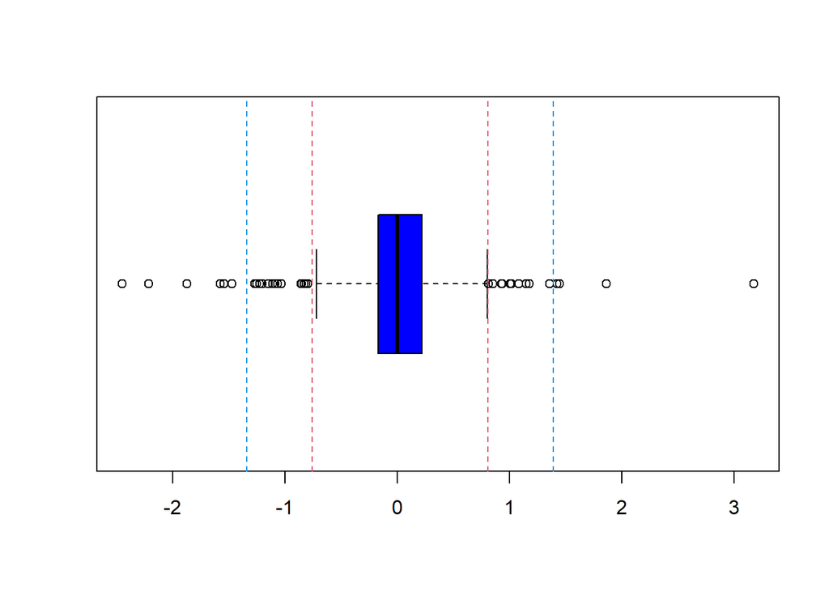

```r
  summary(rstandard(modelo_b))
```

```
##      Min.   1st Qu.    Median      Mean   3rd Qu.      Max.
## -4.971402 -0.337252 -0.000609 -0.000640  0.439318  6.323698
```

Através do gráfico boxplot e da função summary dos resíduos, podemos verificar que os resíduos possuem outliers moderados (entre as linhas azul e vermelha) e serveros (para lá da linha azul). Uma vez que os resíduos representam as diferenças entre os valores observados e os valores ajustados, no caso de um modelo com bom ajuste, seria de esperar que as diferenças fossem as menores possíveis. Podemos verificar também que existem leverage points, indicando que há observações que podem estar a influenciar o nosso modelo.

## **Considerações Finais**

Após esta análise, apesar de o modelo apresentar um bom ajuste, verificamos que as condições de aplicabilidade não são totalmente cumpridas e isso pode enviesar a interpretação e a confiabilidade das inferências feitas a partir do modelo. Transformações nas variáveis, ajustes no modelo ou até mesmo exploração de outros modelos poderiam ser necessárias.